# Project: Investigate TMDB movies data set

- Introduction
- Data Wrangling
- Exploratory Data Analysis
- Conclusions

## Introduction

> we are going to investigate the TMDB data set which contains information about over a 10,000 movies collected from The Movie Database (TMDB),including user ratings and revenue to answer questions like:
> - Do movies with higher budgets have higher revenus or ratings?
> - What is the most popular genre for each of the last five years?
> - What is the production company that achieved the most revenue in 2015 ?

```python
import pandas as pd
import numpy as np
import matplotlib.pyplot as plt
import seaborn
%matplotlib inline
```

## Data Wrangling

### 1. General Properties

```python
df = pd.read_csv('tmdb-movies.csv')
```

```python
df.head()
```

|  | id | imdb_id | popularity | budget | revenue | original_title | cast | homepage | director | tagline | ... | overview | runtime | genres | production_companies | release_date | vote_count | vote_average | release_year | budget_adj | revenue_adj |
| --- | --- | --- | --- | --- | --- | --- | --- | --- | --- | --- | --- | --- | --- | --- | --- | --- | --- | --- | --- | --- | --- |
| 0 | 135397 | tt0369610 | 32.985763 | 150000000 | 1513528810 | Jurassic World | Chris Pratt\|Bryce Dallas Howard\|Irrfan Khan\|Vi... | http://www.jurassicworld.com/ | Colin Trevorrow | The park is open. | ... | Twenty-two years after the events of Jurassic ... | 124 | Action\|Adventure\|Science Fiction\|Thriller | Universal Studios\|Amblin Entertainment\|Legenda... | 6/9/15 | 5562 | 6.5 | 2015 | 1.379999e+08 | 1.392446e+09 |
| 1 | 76341 | tt1392190 | 28.419936 | 150000000 | 378436354 | Mad Max: Fury Road | Tom Hardy\|Charlize Theron\|Hugh Keays-Byrne\|Nic... | http://www.madmaxmovie.com/ | George Miller | What a Lovely Day. | ... | An apocalyptic story set in the furthest reach... | 120 | Action\|Adventure\|Science Fiction\|Thriller | Village Roadshow Pictures\|Kennedy Miller Produ... | 5/13/15 | 6185 | 7.1 | 2015 | 1.379999e+08 | 3.481613e+08 |
| 2 | 262500 | tt2908446 | 13.112507 | 110000000 | 295238201 | Insurgent | Shailene Woodley\|Theo James\|Kate Winslet\|Ansel... | http://www.thedivergentseries.movie/#insurgent | Robert Schwentke | One Choice Can Destroy You | ... | Beatrice Prior must confront her inner demons ... | 119 | Adventure\|Science Fiction\|Thriller | Summit Entertainment\|Mandeville Films\|Red Wago... | 3/18/15 | 2480 | 6.3 | 2015 | 1.012000e+08 | 2.716190e+08 |
| 3 | 140607 | tt2488496 | 11.173104 | 200000000 | 2068178225 | Star Wars: The Force Awakens | Harrison Ford\|Mark Hamill\|Carrie Fisher\|Adam D... | http://www.starwars.com/films/star-wars-episod... | J.J. Abrams | Every generation has a story. | ... | Thirty years after defeating the Galactic Empi... | 136 | Action\|Adventure\|Science Fiction\|Fantasy | Lucasfilm\|Truenorth Productions\|Bad Robot | 12/15/15 | 5292 | 7.5 | 2015 | 1.839999e+08 | 1.902723e+09 |
| 4 | 168259 | tt2820852 | 9.335014 | 190000000 | 1506249360 | Furious 7 | Vin Diesel\|Paul Walker\|Jason Statham\|Michelle ... | http://www.furious7.com/ | James Wan | Vengeance Hits Home | ... | Deckard Shaw seeks revenge against Dominic Tor... | 137 | Action\|Crime\|Thriller | Universal Pictures\|Original Film\|Media Rights ... | 4/1/15 | 2947 | 7.3 | 2015 | 1.747999e+08 | 1.385749e+09 |

5 rows × 21 columns

```python
df.shape
```

```
(10866, 21)
```

> the above data set consists exactly of 10866 movies and 21 columns reprents the movie id, popularity, cast, budget, revenue, vote average, etc..

```python
df.info()
```

```
<class 'pandas.core.frame.DataFrame'>
RangeIndex: 10866 entries, 0 to 10865
Data columns (total 21 columns):
id                      10866 non-null int64
imdb_id                 10856 non-null object
popularity              10866 non-null float64
budget                  10866 non-null int64
revenue                 10866 non-null int64
original_title          10866 non-null object
cast                    10790 non-null object
homepage                2936 non-null object
director                10822 non-null object
tagline                 8042 non-null object
keywords                9373 non-null object
overview                10862 non-null object
runtime                 10866 non-null int64
genres                  10843 non-null object
production_companies    9836 non-null object
release_date            10866 non-null object
vote_count              10866 non-null int64
vote_average            10866 non-null float64
release_year            10866 non-null int64
budget_adj              10866 non-null float64
revenue_adj             10866 non-null float64
dtypes: float64(4), int64(6), object(11)
memory usage: 1.7+ MB
```

> checking for datatypes it shows that they are consistent with the value it presents except for the release_date it should be date/time object but to answer our questions we will consider only the release year so it is fine to keep it as it is.

```python
df.isnull().any(axis=1).sum()
```

```
8874
```

> there are 8874 rows with missing values in the data set.

```python
df.duplicated().value_counts()
```

```
False    10865
True         1
dtype: int64
```

> checking for duplicates it shows that there is one duplicated sample.

### 2.Data Cleaning

#### 2.1. Dropping unneccessary columns

> to answer the above questions we are only concerned about columns:
> - original_title
> - generes
> - production_companies
> - vote_average
> - release_year
> - budget_adj
> - revenue_adj

> we use budget_adj and revenue_adj instead of budget and revenue for a more accurate comparisopn as they show the budget and revenue of the associated movie in terms of 2010 dollars,accounting for inflation over time.

```python
column_keep = ['original_title','genres','production_companies','vote_average','release_year','budget_adj','revenue_adj']
df = df[column_keep]
```

#### 2.2 Remove duplicates

```python
df.drop_duplicates(inplace = True)
df.duplicated().value_counts()
```

```
False    10865
dtype: int64
```

#### 2.3 dealing with missing values

```python
df.info()
```

```
<class 'pandas.core.frame.DataFrame'>
Int64Index: 10865 entries, 0 to 10865
Data columns (total 7 columns):
original_title          10865 non-null object
genres                  10842 non-null object
production_companies    9835 non-null object
vote_average            10865 non-null float64
release_year            10865 non-null int64
budget_adj              10865 non-null float64
revenue_adj             10865 non-null float64
dtypes: float64(3), int64(1), object(3)
memory usage: 679.1+ KB
```

```python
df.isnull().any(axis=1).sum()
```

```
1039
```

> missing values exists in genres , production companies columns and they are 1039 samples which is large so we won't remove them as they won't affect our first question and will only execlude them when answering the other 2 questions.

##### Despite not being presented as nan but revenue column and budget columns also have missing values represented as zeros and as they represent most of our data they will be filled with the mean.

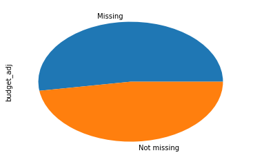

```python
(df['budget_adj']==0).replace([True,False],['Missing','Not missing']).value_counts().plot(kind='pie')
```

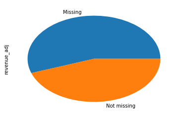

```python
(df['revenue_adj']==0).replace([True,False],['Missing','Not missing']).value_counts().plot(kind='pie')
```

```python
#replacing zeros with mean
df['revenue_adj'].replace(0,df['revenue_adj'].mean(),inplace=True)
df['budget_adj'].replace(0,df['budget_adj'].mean(),inplace=True)
```

```python
#checking
print((df['budget_adj']==0).sum())
print((df['revenue_adj']==0).sum())
```

```
0
0
```

```python
df.shape
```

```
(10865, 7)
```

## Exploratory Data Analysis

### Researching Q1: Do movies with higher budgets have higher revenus or ratings?

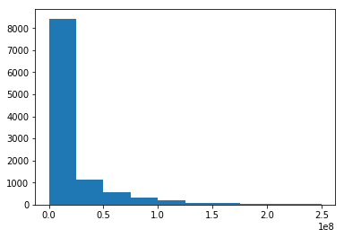

```python
#viewing budget distribution
plt.hist(df['budget_adj'],range=[0,2.5e8])
plt.show()
```

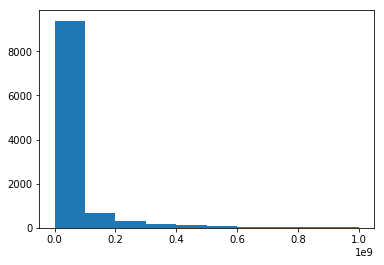

```python
#viewing revenue distribution
plt.hist(df['revenue_adj'],range=[0,1e9])
plt.show()
```

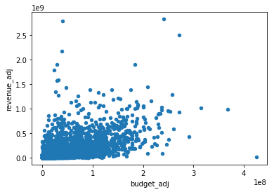

```python
#plot the relation between budget and revenue
df.plot(x='budget_adj' ,y='revenue_adj',kind='scatter')
```

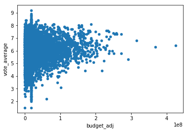

```python
#plot relation between budget and rating
df.plot(x='budget_adj' ,y='vote_average',kind='scatter')
```

### Researching Q2: What is the most popular genre for each of the last five years?

```python
df.dropna(inplace=True)
year_genre = df[(df['vote_average'] >= 7) & (df['release_year'] >= 2010)].copy()
```

> - Then: get a subset of this data frame to get the entries that have multiple gennres in it.

```python
year_genre_multiple = year_genre[year_genre['genres'].apply(lambda x :"|" in x)]
year_genre_sliced = year_genre_multiple.copy()
```

> After that: split these genres as one for each entry.

```python
year_genre_sliced['genres'] = year_genre_sliced['genres'].apply(lambda x : x.split("|"))
genre_list=[]

for i,sample in year_genre_sliced.iterrows():
        for genre in sample['genres']:
            item = sample.copy()
            item['genres'] = genre
            genre_list.append(item)
```

> When: we finish spliting we append these value to our year_genre dataframe and drop the indexes with mulitple genres from the year_genre dataframe.

```python
single_genre = pd.DataFrame(genre_list)
year_genre.drop(year_genre_multiple.index,inplace=True)
year_genre = year_genre.append(single_genre,ignore_index=True)
```

> - Finally: we group our final dataframe according to the year, sum the number of movies with high rating and plot for each year.

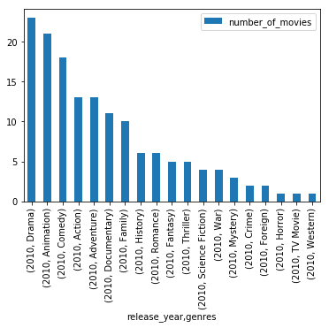

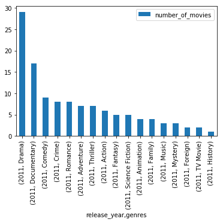

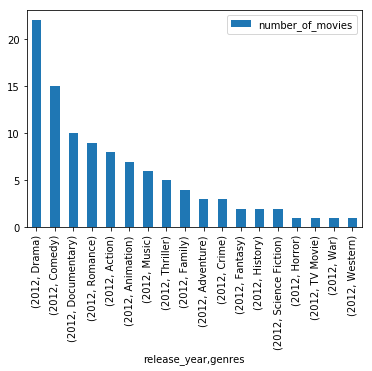

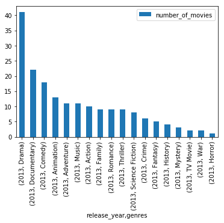

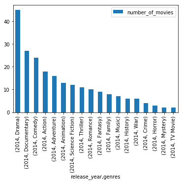

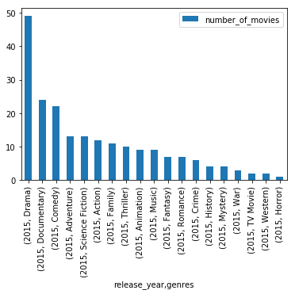

```python
year_genre = pd.DataFrame(year_genre.groupby(['release_year'])['genres'].value_counts())
year_genre.rename(columns={'genres':'number_of_movies'}, inplace=True)
for year,new_df in year_genre.groupby(level=0):
    new_df.plot(kind='bar')
```

### Researching Q3: What is the production company that achieved the most revenue in 2015 ?

> To get the company that achieved the most revenue we:

> ***First:*** get the entries of 2015 only.

```python
prod_company_2015 = df[df['release_year'] == 2015].copy()
```

> Then: get a subset of this data frame to get the entries that have multiple production companies in it.

```python
prod_company_2015_multiple = prod_company_2015[prod_company_2015['production_companies'].apply(lambda x :"|" in x)]
prod_company_2015_sliced = prod_company_2015_multiple.copy()
```

> After that: split these companies as one for each entry.

```python
prod_company_2015_sliced['production_companies'] = prod_company_2015_sliced['production_companies'].apply(lambda x : x.split("|"))
company_list=[]
for i,sample in prod_company_2015_sliced.iterrows():
        for prod in sample['production_companies']:
            item = sample.copy()
            item['production_companies'] = prod
            company_list.append(item)
```

> When: we finish spliting we append these value to our 2015 dataframe and drop the indexes with mulitple companies from the 2015 dataframe.

```python
single_company = pd.DataFrame(company_list)
prod_company_2015.drop(prod_company_2015_multiple.index,inplace=True)
prod_company_2015 = prod_company_2015.append(single_company,ignore_index=True)
```

> Finally: we group our final dataframe according to the company's name sum it revenue and plot the top 10 companies.

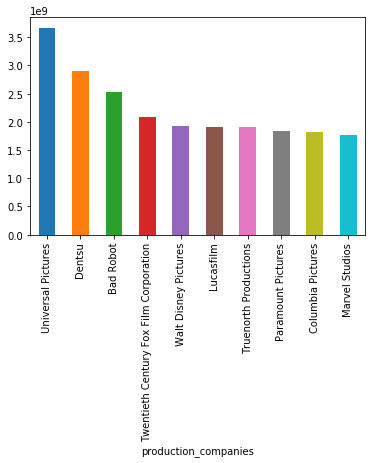

```python
prod_company_2015.groupby(['production_companies'])['revenue_adj'].sum().sort_values(ascending = False)[0:10].plot(kind='bar')
```

## Conclusions

### After exploring the dataset to answer the given questions we can say that:

##### From the budget/revenue plot and according to the given and shown data only we notice that :

> - for many cases movies with higher budgets have higher revenue
> - But in other cases also it may be same as movies with lower budget.
> - and there are some cases that the budget is lower than the others but achieved more revenue

##### From the budget/vote average plot we notice that :

> - there is no relation between the budget of these movies and vote average

##### From the production companies/revenue plot we notice that :

> Universal Pictures achieved the highest revenue in 2015.

```python
from subprocess import call
call(['python', '-m', 'nbconvert', 'Investigate_a_Dataset.ipynb'])
```